# Land use effects on Pacific Giant Salamander population and weight

A report prepared for ESM 206

Maggie Brickner

12/04/2019

### Introduction

The Pacific Giant Salamander or Coastal Giant Salamander (*Dicamptodon tenebrosus*) is among the largest terrestrial salamanders in the world. They live in coastal, wet forests usually near water. Growing up to 30 cm (11.8 inches) long, they feed on insects and slugs as well as other amphibians and even small rodents (Naish 2016). Logging is a major threat to the Pacific Giant Salamander. In previous studies logging has been shown to severely decrease the population of Pacific Giant Salamander larvae in streams (AmphibiaWeb 2010). Here I use data collected along Mack Creek within the H.J. Andrews Experimental Forest located in the Cascade Mountain Range in Oregon. Data has been collected on Pacific Giant Salamanders in this area since 1993 in areas that were clearcut in 1963 and in an old growth forest (Gregory 2016).

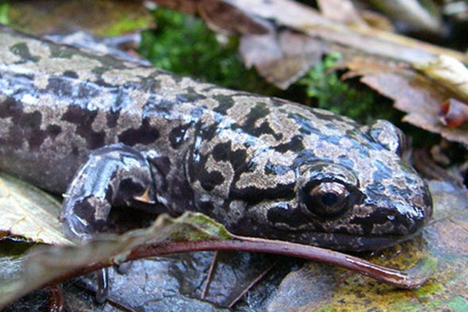

### Data and Methods

*Dicamptodon tenebrosus* data used here has been collected since 1993 and is a part of an ongoing study within the [Andrews Experimental Forest Long-Term Ecological Research Program (LTER)](https://andrewsforest.oregonstate.edu/). Data collection was initated by Stanley V. Gregory at Oregon State University. An annual electrofishing survey of aquatic vertebrates number and sizes, including weight (g), was collected along Mack Creek within the LTER site. For more information on data collection and methods, see the [metadata](https://portal.edirepository.org/nis/metadataviewer?packageid=knb-lter-and.4027.12). Total Pacific Giant Salamander counts were first compared between old growth and clearcut areas along the creek as well as by observation location within each forest type. Creek channel classification observation locations include pool, casecade, and side-channel. A chi-square test for independence was conducted ($\alpha$ = 0.05 throughout). A single-factor ANOVA was then conducted on salamander weight based on the three creek habitats. All analyses were completed using R software version 1.2.5001.

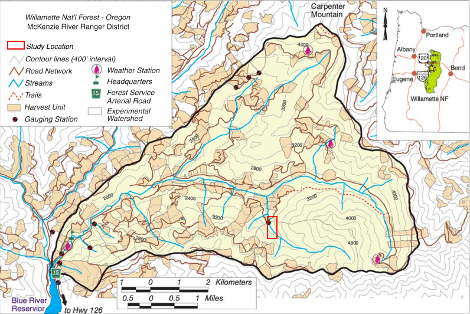

### Results

##### A. Pacific Giant Salamander Counts

Prior logging of forests along creeks has previously been found to have a significant negative effect on Pacific Giant Salamander populations(AmphibiaWeb 2010). The Andrews Experimental Forest survey area included an old growth forest with trees over 500 years old as well as an area that was clearcut around 1963 (Gregory 2016). Here I compare counts within the Andrews Experimental Forest between these two forest types from 1993 to 2017. The data does not show as severe as a difference in salamander counts between clearcut and old growth forests as has previously been noted. Since the forest was clearcut 30 years before the survey began, it could indicate hope for restoring salamander populations as natural reforestation occurs.

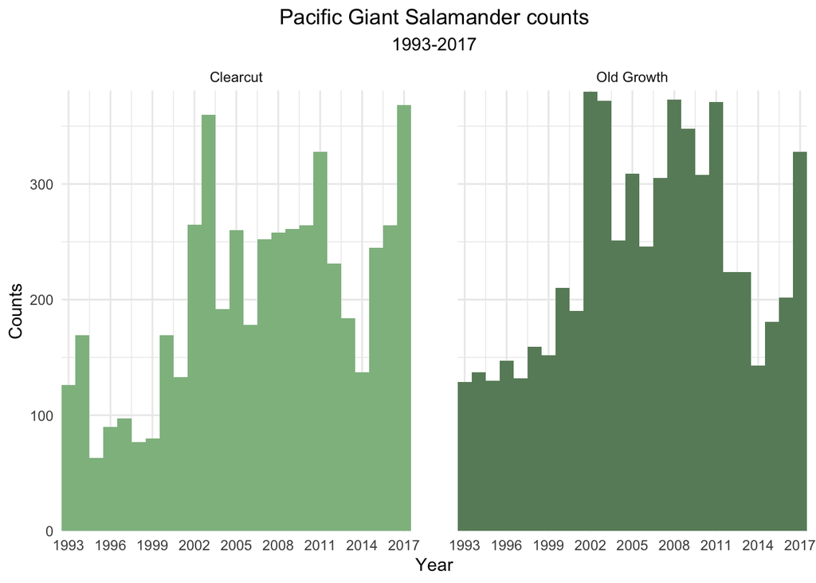

*Figure 3.* *Pacific Giant Salamander counts from 1993 when the study began up to the most recent available data from 2017.The data does not show as severe as a difference in salamander counts between clearcut and old growth forests as has previously been noted.*

##### B. Salamander Counts by Channel Classification in Clearcut and Old Growth Forests

Data from 2017 only was selected and compared accross each observation channel classification and forest classification (old growth or clearcut). Based on the observation of trends in *Table 1*, it does not appear that forest classification has a strong impact on where salamanders stay within the channel.

*Table 1.* *Salamander counts and proportions in old growth (n = 328) and clearcut forests (n = 368). Salamanders in both forest classifications seem to have a preference for cascades within the Mack Creek channel.*

| 2017 Salamander Location Section | 2017 Salamander Location Cascade | 2017 Salamander Location Pool | 2017 Salamander Location Side Channel |
| --- | --- | --- | --- |
| Clearcut | 247 (67.1%) | 31 (8.4%) | 90 (24.5%) |
| Old Growth | 201 (61.3%) | 45 (13.7%) | 82 (25.0%) |

##### C. Salamander Count Significance Channel Classification in Clearcut and Old Growth Forests

A chi-square test was conducted ($\alpha$ = 0.05) to see if there is a significant effect of forest classification on the channel classification where salamanders were found.

H<sub>0</sub>: There is no significant effect of forest classification (clear cut or old growth) on channel classification where salamanders were found.

H<sub>A</sub>: There is a significant effect of forest classification on channel classification where salamanders were found.

There is not sufficient evidence to reject the null hypothesis ($\chi^2$(2) = 5.39, *p* = 0.07). Forest classification does not have a significant impact on where in the channel salamanders were found.

##### D. Pacific Giant Salamander Weight and Forest Classification

Next, channel classificatin was repoooled and 2017 measured salamander weight (g) was compared based on forest classification using a two-sample t-test($\alpha$ = 0.05).

H<sub>0</sub>: There is no significant difference in mean Pacific Giant Salamander weights based on forest classification (clear cut or old growth).

H<sub>A</sub>: There is a significant difference in mean Pacific Giant Salamander weights based on forest classification.

Mean 2017 salamander weight (g) measured in old growth forest (6.58) within the Andrews Experimental Forest and forest clear cut around 1963 (7.78) does not differ significantly (t(692.79) = 1.67 *p* = 0.096).

##### E. Pacific Giant Salamander Weight and Channel Classification

Again using 2017 data, mean salamander weight between channel locations (classifications) was measured. The three locations compared were pools, cascades, and side-channels.

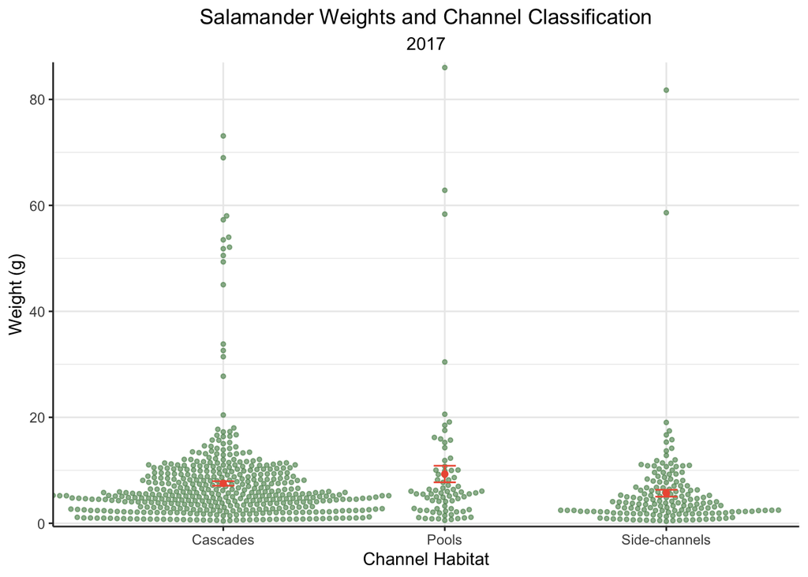

*Figure 4.* *Mean salamander weight based upon location within the Mack Creek channel where they were observed. Means are indicated by red dot for each channel classification. Standard error bars for each location are also included.*

Salamander weight does not appear to be equally distributed in any of the different channel habitats. However, all sample sizes are large enough to assume normality based on the Central Limit Theorem. In order to compare mean salamander weight accross the three different channel classifications (pool, cascade, and side-channels) I will be using a single-factor ANOVA where Pacific Giant Salamander weight (g) is the factor and channel classifications are the levels.

In order to verify that this is the appropriate method of analysis a Levene test for equal variance was conducted. There is not substantial evidence to reject the null hypothesis, There is not significant difference in salamander weight variance between the three channel classifications.

| 2017 Salamander Weight Based on Channel Location Channel Classification | 2017 Salamander Weight Based on Channel Location Mean weight | 2017 Salamander Weight Based on Channel Location Standard deviation | 2017 Salamander Weight Based on Channel Location n | 2017 Salamander Weight Based on Channel Location Standard Error | 2017 Salamander Weight Based on Channel Location Variance |
| --- | --- | --- | --- | --- | --- |
| Cascade | 7.520850 | 9.027747 | 447 | 0.4269978 | 81.50021 |
| Pool | 9.297500 | 13.622957 | 76 | 1.5626603 | 185.58494 |
| Side-channel | 5.676646 | 8.265256 | 164 | 0.6454081 | 68.31446 |

Pacific Giant Salamanders observed in pools along Mack Creek weighed significantly more than those observed in side-channels (single-factor ANOVA with post-hoc Tukey’s HSD, F(2, 684) = 4.22, *p* = 0.015). See *Table 2.* for actual values.

This conclusion is logical considering that side-channels to the creek are most likely smaller whereas pools within the creek would have a greater volume of water and therefore would be more welcoming to larger salamanders.

Although the conclusion is logical and was responsible based on the Central Limit Theorem and Levene’s test for equal variance, the mean weights of salamanders do appear to be psoitively skewed for all three channel classifications. It may be more accurate to compare based on medians.

### References

AmphibiaWeb. 2010. Dicamptodon tenebrosus: Pacific Giant Salamander. University of California, Berkeley. Retrieved from http://amphibiaweb.org/species/3867

Gregory S. V. 2016. Aquatic Vertebrate Population Study in Mack Creek, Andrews Experimental Forest, 1987 to present. Environmental Data Initiative. Retrieved from https://doi.org/10.6073/pasta/5de64af9c11579266ef20da2ff32f702

Naish, D. 2016. The Pacific Giant Salamanders. Scientific American Tetrapod Zoology Blog. Retrieved from https://blogs.scientificamerican.com/tetrapod-zoology/the-pacific-giant-salamanders/

United States Department of Agriculture. 2003. H.J. Andrews Experimental Forest Brochure. Forest Service. Retrieved from https://andrewsforest.oregonstate.edu/sites/default/files/lter/pubs/pdf/pub3654.pdf